# Session 8 — Implementing Scoring & Victory

Application State Management 🏆

You’re about to add the most satisfying part of any game — scoring and victory! This guide walks you through implementing a complete scoring system, managing complex application state, and creating your first independent React component. Ready to make your trivia game feel like a real achievement? Let’s go!

- Understanding Application State
- Adding Score Tracking
- Implementing Score Updates
- Adding Cache Clearing
- Updating Reset Functionality
- Solo Mission: GameOver Component
- Essential Terms
- Ask the AI

## ☁️ Accessing Your Codespace

Visit github.com/codespaces to relaunch your Codespace from Session 7.

## 🧠 Understanding Application State

Before we dive into scoring, let’s understand how **application state** differs from the component state you’ve used before.

**Application state** is the complete picture of your game’s current condition — everything from the player’s score to which zones are completed. Think of it as your game’s “save file” that tracks all progress and achievements.

### State Categories in Your Game

Your `GameContext` manages five categories of state:

| Category | Purpose | Examples |
| --- | --- | --- |
| **Game State** | Core game progress | `score`, `screen`, `zoneProgress` |
| **Quiz State** | Current quiz session | `currentQuestions`, `currentQuestion`, `correctAnswers` |
| **Audio** | Sound controls | `music` settings |
| **Actions** | Game logic functions | `recordCorrectAnswer`, `resetGame` |
| **Controls** | UI state setters | `setScreen`, `setIsQuizVisible` |

### Visualizing Game State

Think of your `GameContext` as the brain of your game — it keeps track of everything that’s happening behind the scenes. The `useGame` hook provides access to this brain from any component that needs it. The mind map below breaks down how your game’s state is organized, with a spotlight on **actions** — these are the functions that drive your game logic and help different parts of your app work together:

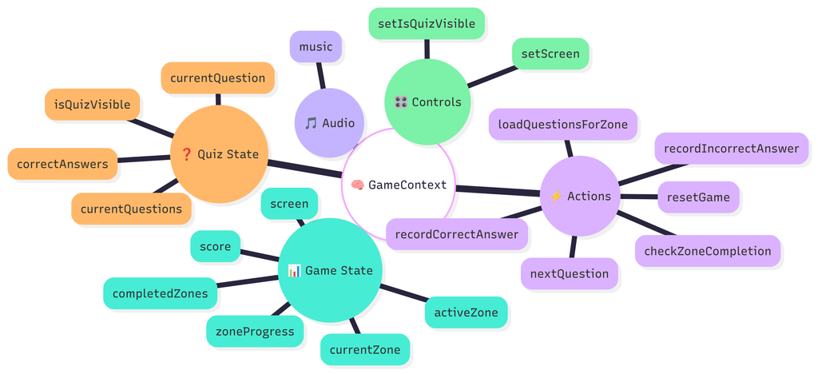

*Figure: GameContext Mind Map*

**Application state management** is what separates simple websites from complex, interactive applications. Your scoring system will coordinate multiple pieces of state to create a cohesive game experience where every action has consequences and every achievement is tracked.

## 🏆 Adding Score Tracking

Let’s add a scoring system that tracks player performance and displays it prominently in your game’s HUD.

1. **Open** `src/context/GameContext.jsx` and add score state inside the GameProvider function

   ```javascript
   const [score, setScore] = useState(0);
   ```

2. **Make** score available by adding it to the Context value

   ```javascript
   <GameContext value={{
     // GAME STATE
     screen,
     score,
     zoneProgress,
     // ... rest of existing properties
   ```

3. **Open** `src/components/HUD.jsx` and add a Scoreboard component at the top of the file

   ```javascript
   function Scoreboard() {
     const { score } = useGame();
     return <div className="score-display">Score: {score}</div>;
   }
   ```

4. **Update** HUD component to render both components using a React Fragment (`<>...</>`)

   ```javascript
   // Replace this single line:
   return <CurrentZone />;

   // With this Fragment structure:
   return (
     {/* Fragment groups components without extra DOM wrapper */}
     <>
       <Scoreboard />
       <CurrentZone />
     </>
   );
   ```

5. **Test** by navigating to the game screen and verifying Score: 0 appears in HUD

The **Scoreboard component** demonstrates the single responsibility principle — it has one job: display the current score. This modular approach makes your code easier to maintain and test.

## 📊 Implementing Score Updates

Now let’s make the score actually change based on player performance with point rewards and penalties.

1. **Open** `src/context/GameContext.jsx` and find the `recordCorrectAnswer` function, then add points for correct answers

   ```javascript
   const recordCorrectAnswer = () => {
     setCorrectAnswers((prev) => prev + 1);
     setScore((prev) => prev + POINTS_PER_CORRECT);
   };
   ```

2. **Find** the `recordIncorrectAnswer` function and add point deduction

   ```javascript
   const recordIncorrectAnswer = () => {
     // Prevent score from going negative
     setScore((prev) => Math.max(0, prev - POINTS_PER_CORRECT));
   };
   ```

3. **Test** by clicking zone, answering questions, and observing score changes
   - Correct answer → +100 points
   - Incorrect answer → -100 points (but never below 0)

**Updater functions** like `setScore((prev) => prev + 100)` are crucial when updating state based on the previous value. React batches state updates, so using the previous value ensures accurate calculations even when multiple updates happen quickly.

## 🗄️ Adding Cache Clearing

Let’s add cache clearing functions to remove stored questions when zones are completed or the game resets.

1. **Open** `src/services/trivia.js` and add cache clearing functions at the end of the file

   ```javascript
   export function clearQuestionCache(zoneId) {
     const cacheKey = getCacheKey(zoneId);
     localStorage.removeItem(cacheKey);
   }

   export function clearAllQuestionCache() {
     Object.keys(localStorage)
       .filter((key) => key.startsWith("trivia_questions_zone_"))
       .forEach((key) => localStorage.removeItem(key));
   }
   ```

2. **Import** the cache functions into GameContext.jsx

   ```javascript
   import {
     fetchQuestions,
     clearQuestionCache,
     clearAllQuestionCache
   } from "../services/trivia";
   ```

3. **Update** the `checkZoneCompletion` function to clear the current zone’s cached questions when completed

   ```javascript
   const checkZoneCompletion = () => {
     if (activeZone === null || currentQuestions.length === 0) return;

     const questionsNeeded = Math.ceil(
       currentQuestions.length * PASS_PERCENTAGE
     );
     const passed = correctAnswers >= questionsNeeded;

     if (passed) {
       setZoneProgress((prev) => ({
         ...prev,
         [activeZone]: { completed: true },
       }));

       clearQuestionCache(activeZone);

       if (activeZone === ZONES.length - 1) {
         setScreen(SCREENS.GAME_OVER);
       }
     }
   };
   ```

**Cache management** prevents stale data from affecting gameplay. When players complete a zone, clearing its cache ensures they get fresh questions if they replay. The `Object.keys()` and `filter()` pattern is an effective way to find and remove related localStorage entries.

## 🔄 Updating Reset Functionality

Let’s update the reset function to properly clear all game state and cached data for a fresh start.

1. **Find** the `resetGame` function in GameContext.jsx and update it

   ```javascript
   const resetGame = () => {
     setScore(0);
     setZoneProgress({
       0: { completed: false },
       1: { completed: false },
       2: { completed: false },
     });
     setIsQuizVisible(false);
     setCurrentQuestions([]);
     setCurrentQuestion(0);
     setCorrectAnswers(0);
     clearAllQuestionCache();
   };
   ```

2. **Test** the reset functionality by completing a zone and then using React DevTools to trigger `resetGame()`

**Complete state reset** ensures players can start fresh without any lingering data from previous games. This includes both React state and localStorage cache, providing a clean slate for new gameplay sessions.

## 🎖️ Solo Mission: GameOver Component

Now for the exciting part — you’ll create a GameOver component that celebrates player achievements and allows them to play again! You’ve got all the tools — now it’s time to build your own victory screen using everything you’ve learned.

### 1. Create the Component Foundation

- **Create** `src/components/GameOver.jsx` with function component and default export
- **Return** JSX with div `className="game-over"` containing h1 congratulations message
- **Import** `GameOver` into `App.jsx` and add conditional rendering for `SCREENS.GAME_OVER`
- **Test** by using React DevTools → setting `screen` to “gameover” → Component appears

### 2. Add Score Display

- **Import** `useGame` hook and destructure `score`
- **Add** div with `className="final-score"` displaying `Final Score: {score}`
- **Test** by checking score display → Shows current game score

### 3. Add Play Again Functionality

- **Create** click handler calling `resetGame` and `setScreen(SCREENS.SPLASH)`
- **Import** and render `GameButton` with “Play Again” text and `"primary"` variant
- **Test** by clicking Play Again → Game resets → Returns to splash screen

### Testing Tips

- **Quick testing** by using React DevTools to change `screen` state to “gameover” (find `GameProvider` → hooks → screen)
- **Full testing** by completing all three zones to naturally trigger GameOver screen
- **Verify** final score displays correctly and Play Again button resets everything

### **Requirements Checklist**

Your completed GameOver component must:

- Export function component as default
- Wrap content in div with `className="game-over"`
- Display congratulations using h1 element
- Import `GameButton`, `useGame`, `SCREENS`
- Show final score in div with `className="final-score"`
- Include Play Again button using `GameButton` with `"primary"` variant
- Reset game and navigate to splash screen when Play Again is clicked
- Display when screen state equals `SCREENS.GAME_OVER` in `App.jsx`

### 🔍 Reference Files

- **`SplashScreen.jsx`**: Component structure, `GameButton` usage, `useGame` hook, screen navigation, click handler patterns
- **`HUD.jsx`**: Accessing `score` from `useGame` hook
- **Session 2 guide**: `GameButton` props and component export patterns
- **Session 3 guide**: `SCREENS` constants and navigation patterns

This challenge combines everything you’ve learned: component creation, props, shared state, event handling, and conditional rendering. Following guided steps without code examples builds confidence in applying React patterns — you’re connecting concepts rather than copying code.

## 📚 Essential Terms

*Quick reference for the key concepts you just learned:*

| Term | Definition | Why it matters |
| --- | --- | --- |
| 🏗️ application state | The complete condition of an application at a specific moment in time, encompassing all the information it needs to function correctly. | Your GameContext manages all application state — screen, score, zone progress — making it accessible to any component through useGame. |
| 🔄 updater function | A function passed to setState that receives the previous state value and returns the new state. | Essential for score calculations — ensures accurate updates even when React batches multiple state changes. |
| 🎯 single responsibility principle | Design pattern where each component or function has one clear, focused purpose. | Your Scoreboard component only displays score — this separation makes code easier to test and maintain. |

## 🤖 Ask the AI — Implementing Scoring & Victory

You just implemented a complete scoring system, managed complex application state, and built your first independent React component — excellent work!

Now let’s deepen your understanding of state management patterns, component architecture, and development practices. Here are the most impactful questions to ask your AI assistant about today’s session:

- **How does application state differ from component state, and when should I use each?**
- **Why are updater functions important for state that depends on previous values?**
- **What are some common patterns for resetting application state in React apps?**
- **What makes a component follow the single responsibility principle?**
- **How do you decide what props a new component needs when building it from scratch?**